# Atividade_3_5_site_Mariana_Faitanin

```r
# selecionar variaveis
brauna <- brauna_gbif$data %>%
  dplyr::select(scientificName, decimalLatitude, decimalLongitude) %>%
  distinct()
```

```r
library(leaflet)
```

```r
# conferir no mapa
brauna %>%
  leaflet() %>%
  addTiles() %>%
  addMarkers(~decimalLongitude,
             ~decimalLatitude)
```

[interactive chart not shown]

#A melaxolylon brauna é uma espécies endêmica do Brasil, com ocorrência nas regiçoes Nordeste (Alagoas, Bahia, Paraíba, Pernambuco, Rio Grande do Norte, Sergipe)e Sudeste (Espírito Santo, Minas Gerais, Rio de Janeiro, São Paulo). Através do gráfico plotado com os dados de latitude e ocorrência, podemos perceber que essa espécie apresenta uma distribição dispersa entre os graus -25 a -10.Enretando, quando plotamos os mesmo pontos de ocorrência para a variável longitude, podemos observar que a ditribuição dessa espécie apresenta um pico entre os graus -45 a -40, região correspondente a Mata Atlântica e a parte da caatinga e cerrado.

[output not shown]

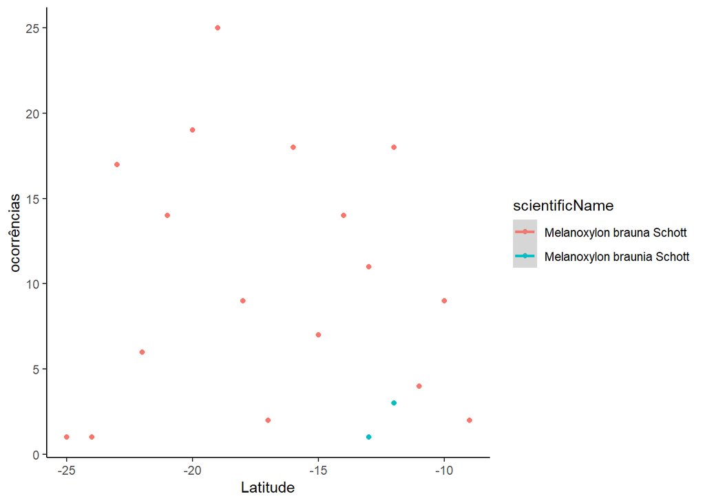

```r
brauna %>%
  mutate(lat = round(decimalLatitude)) %>%
  group_by(lat, scientificName) %>%
  summarise(occ = length(scientificName)) %>%
  ggplot(aes(y = occ, x = lat, color = scientificName)) +
    geom_point() +
    geom_smooth() +
    theme_classic() +
    labs(x = "Latitude", y = 'ocorrências')
```

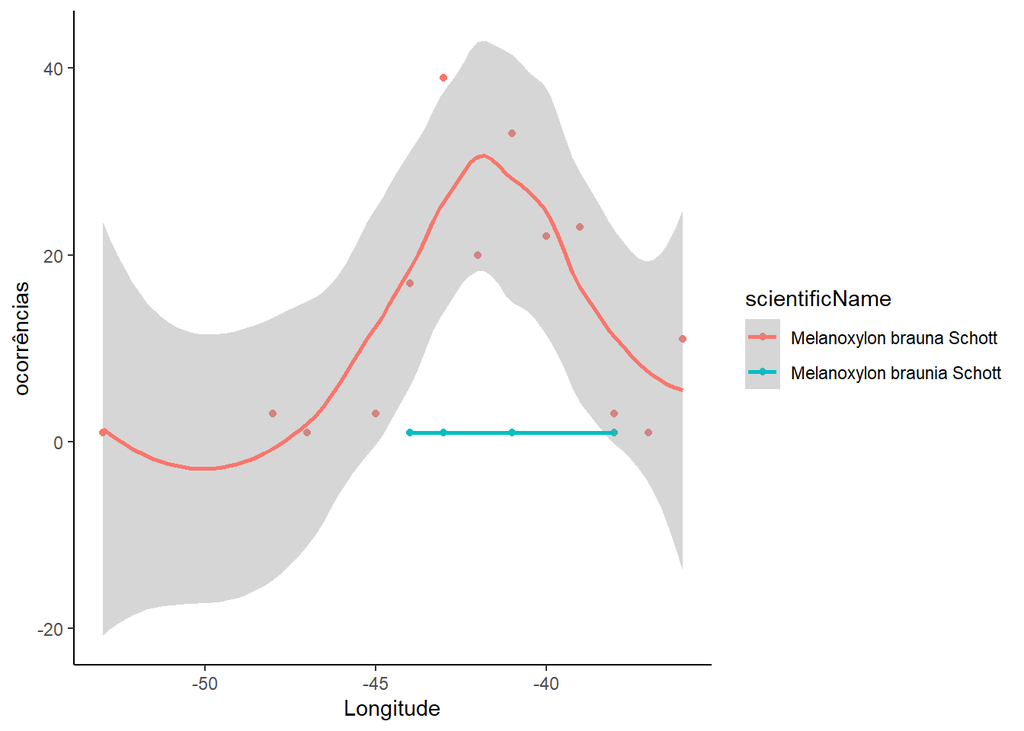

```r
brauna %>%
  mutate(long = round(decimalLongitude)) %>%
  group_by(long, scientificName) %>%
  summarise(occ = length(scientificName)) %>%
  ggplot(aes(y = occ, x = long, color = scientificName)) +
    geom_point() +
    geom_smooth() +
    theme_classic() +
    labs(x = "Longitude", y = 'ocorrências')
```

#ATENÇÃO: Melanoxylon brauna e Melanoxylon braunia são Sinônimos e Variante ortográfica, por isso foi considerado os dois.

#Comando para exportar a tabela em formado .xlsx

```r
library(writexl)
write_xlsx(brauna_gbif1,"C:\\ciencia-colab\\Atividade-final\\trab-final\\Trabalho-Final1-Mariana-Faitanin\\brauna-gbif-ponto1.xlsx")
```

[output not shown]